# HW1

Trevor Rizzi

2022-10-02

## Homework 1

### Question 1

Supervised learning: In supervised learning, the Y data is actually known and used for training the model. Model is given the observed output and input (from lecture slides day 1) Unsupervised learning: The response data is unknown, so the model is only given predictors and is to come up with a fit based on them

Supervised learning trains itself based on inputs and outputs while unsupervised has to determine the structure between inputs on its own.

### Question 2

In a regression model, Y is quantitative (numerical values) whereas classification is qualitative (categorical values) - (lecture slides day 1). In machine learning a quantitative model will be numerically based and a classification model will have categorical labels instead.

### Question 3

Regression commonly used metrics: age, height Classification commonly used metrics: color, win/ loss

### Question 4

Descriptive models: “Choose a model to best visually emphasize a trend in data” (lecture slides day 1) Inferential models: “Aim is to test theories … State relationship between outcomes and predictors” (lecture slides day 1) Predictive models: “Aim is to predict Y with minimum reducible error … Not focused on hypothesis tests” (lecture slides day 1)

### Question 5

Mechanistic: Parametric, uses the parametric form to predict what could be observed. Emperically-driven: Non-parametric, uses real observations to develop a theory.

Mechanistic models are typically less flexible but can that can differ based on # of parameters. Emperically driven models require a larger quantity of observations

I think empirically-driven models are easier to understand since it is coming to a theoretical conclusion based off of real world events/obersvations. It is more straight forward.

It is ideal to simultaneously achieve a low variance and low bias. A simple model which is typically mechanistic will have a high bias and low variance. An empirical model will have a high flexibility and therefore a low bias and high variance

### Question 6

Given a voter’s profile/data, how likely is it that they will vote in favor of the candidate? This is predictive as the aim is to predict a Y (whether they will vote for a candidate) with minimum error. How would a voter’s likelihood of support for the candidate change if they had personal contact with the candidate? This is inferential as it is trying to establish a relationship between the outcome (likelihood of support) and predictors(contact with candidate)

```r
install.packages("tidyverse",repos = "http://cran.us.r-project.org")
install.packages("tidymodels", repos = "http://cran.us.r-project.org")
install.packages("ISLR", repos = "http://cran.us.r-project.org")
library(tidyverse)
library(tidymodels)
library(ISLR)
```

### Exercise 1

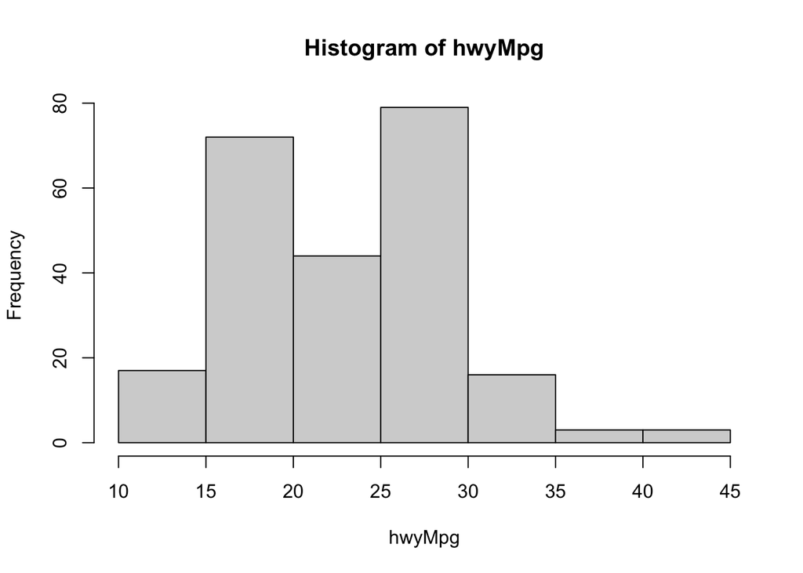

```r
hwyMpg <- mpg$hwy
hist(hwyMpg)
```

The histogram is bimodal, with peaks its between 15-20 mpg and 25-30 mph suggesting that these ranges are the most common highway mileages.